# Problem Set 2

Michael Adamson

```r
#libraries
library(wooldridge)
library(ggplot2)
```

# Plot marginal effect:

```r
# model1

data(wage2)
wage2$educ_exper = wage2$educ*wage2$exper
mod1 <- lm(data = wage2, lwage ~ educ + exper + educ_exper)
summary(mod1)
```

```
##
## Call:
## lm(formula = lwage ~ educ + exper + educ_exper, data = wage2)
##
## Residuals:
##      Min       1Q   Median       3Q      Max
## -1.88558 -0.24553  0.03558  0.26171  1.28836
##
## Coefficients:
##              Estimate Std. Error t value Pr(>|t|)
## (Intercept)  5.949455   0.240826  24.704   <2e-16 ***
## educ         0.044050   0.017391   2.533   0.0115 *
## exper       -0.021496   0.019978  -1.076   0.2822
## educ_exper   0.003203   0.001529   2.095   0.0365 *
## ---
## Signif. codes:  0 '***' 0.001 '**' 0.01 '*' 0.05 '.' 0.1 ' ' 1
##
## Residual standard error: 0.3923 on 931 degrees of freedom
## Multiple R-squared:  0.1349, Adjusted R-squared:  0.1321
## F-statistic: 48.41 on 3 and 931 DF,  p-value: < 2.2e-16
```

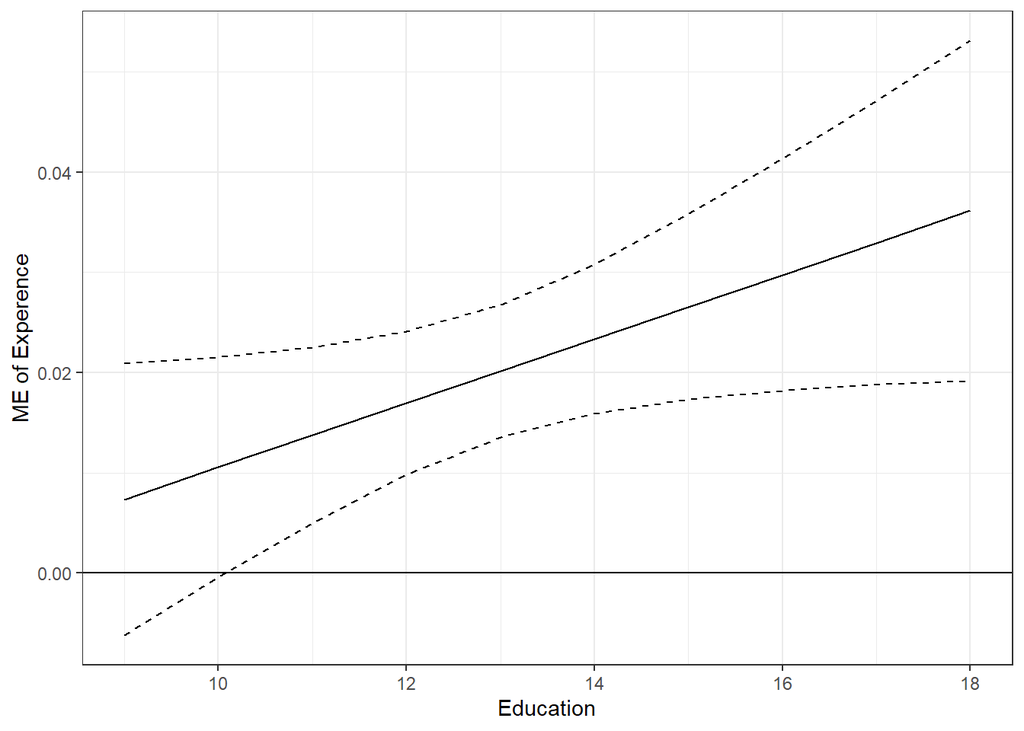

```r
# plot experience by education

me_exper <- mod1$coef[3]+mod1$coef[4]*wage2$educ
se_exper <- sqrt(vcov(mod1)[3,3]+(wage2$educ^2)*vcov(mod1)[4,4]+2*wage2$educ*vcov(mod1)[3,4])
ggplot(wage2)+
  geom_line(aes(x = educ, y = me_exper))+
  geom_line(aes(x = educ, y = me_exper - 2*se_exper), linetype = 2)+
  geom_line(aes(x = educ, y = me_exper + 2*se_exper), linetype = 2)+
  geom_hline(aes(yintercept = 0))+
  ylab("ME of Experence")+
  xlab("Education")+
  theme_bw()
```

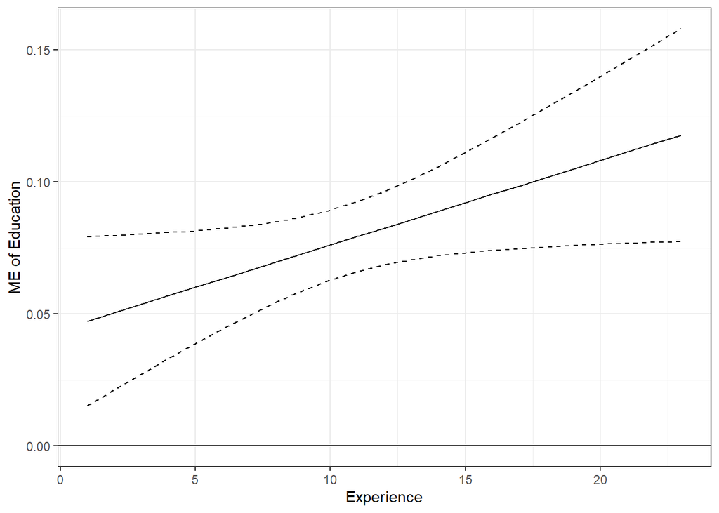

```r
# plot education by experience

me_educ <- mod1$coef[2]+mod1$coef[4]*wage2$exper
se_educ <- sqrt(vcov(mod1)[2,2]+(wage2$exper^2)*vcov(mod1)[4,4]+2*wage2$exper*vcov(mod1)[2,4])
ggplot(wage2) +
  geom_line(aes(x = exper, y = me_educ)) +
  geom_line(aes(x = exper, y = me_educ - 2*se_educ), linetype = 2)+
  geom_line(aes(x = exper, y = me_educ + 2*se_educ), linetype = 2)+
  geom_hline(aes(yintercept = 0))+
  ylab("ME of Education")+
  xlab("Experience")+
  theme_bw()
```

# Question C3(i):

$log(wage) = \beta_{0} + \beta_{1}educ + \beta_{2}exper + \beta_{3}educ*exper + u$

$Δlog(wage)/Δeduc = \beta_{1} + \beta_{3}*exper$

If we hold all other factors constant, $\beta_{2}exper$, $\beta_0$, and $u$ are removed, then by taking the derivative, and dividing by $Δeduc$ we are left with $\beta_{1} + \beta_{3}*exper$

# Question C3(ii):

An appropriate alternative is that an interaction with exper either increases or decrease the marginal effect of educ (i.e. H1)

H1: H0 not true

# Question C3 (iii):

From the plot of marginal effect of experience by education, we can see that we only accept the null (i.e. that the marginal effect of experience on education is zero) for values under 10 years of education. Above 10 years of education, we can reject the null hypothesis. Since there are very few observations under 10 years of education, as a proportion of the data set, we are justified in rejecting the null hypothesis and keeping the interaction in the model.

. . .